# Effects of Negative Versus Positive Mood Induction on Depression and Anxiety

- Show All Code
- Hide All Code
- View Source

PSY 120L Reproducible Analysis Report

Author

Student Name

Published

May 14, 2026

## About This Report

This reproducible report documents the data preparation, variable construction, descriptive statistics, primary analyses, and figures for this study.

The report is intended to accompany a manuscript-style research paper. It is not the full paper itself. Instead, it shows how the reported analyses were produced from the dataset using a transparent and reproducible Quarto workflow.

## Study Overview

This study examined whether depression and anxiety scores differed by mood condition, neuroticism group, and their interaction.

The design included one manipulated independent variable and one categorical moderator:

- Mood condition: negative mood induction versus positive mood induction
- Neuroticism group: lower neuroticism versus higher neuroticism

The dependent variables were depression scores and anxiety scores.

The primary analyses tested whether mood condition, neuroticism group, and their interaction predicted each outcome.

## Setup and Software Environment

This section loads the packages used for data preparation, scale construction, statistical modeling, estimated marginal means, and figures.

**Load Packages**

```r
library(tidyverse)  # data manipulation + plotting
library(psych)      # scale construction + reliability
library(afex)       # ANOVA models + effect sizes
library(emmeans)    # estimated marginal means + confidence intervals
```

## Data Source and Analysis Dataset

The dataset was imported from the project `data` folder. The imported dataset was saved as `study_raw` so that the original file remained unchanged throughout the report.

A smaller analysis dataset was then created for the current analyses. This dataset retained the study condition variables, demographic variables, neuroticism items, depression items, and anxiety items needed for variable preparation and analysis.

### Import Dataset

```r
study_raw <- read_csv("data/120L_practice_data.csv")
```

### Check Imported Dataset

```r
dim(study_raw)
```

```
[1] 146 124
```

```r
names(study_raw)
```

```
  [1] "StartDate"             "EndDate"               "Status"
  [4] "IPAddress"             "Progress"              "Duration (in seconds)"
  [7] "Finished"              "RecordedDate"          "ResponseId"
 [10] "RecipientLastName"     "ExternalReference"     "LocationLatitude"
 [13] "LocationLongitude"     "DistributionChannel"   "UserLanguage"
 [16] "moodcond"              "filmtype"              "sex"
 [19] "pet"                   "age"                   "neo1"
 [22] "neo2"                  "neo3"                  "neo4"
 [25] "neo5"                  "neo6"                  "neo7"
 [28] "neo8"                  "neo9"                  "neo10"
 [31] "neo11"                 "neo12"                 "neo13"
 [34] "neo14"                 "neo15"                 "neo16"
 [37] "neo17"                 "neo18"                 "neo19"
 [40] "neo20"                 "neo21"                 "neo22"
 [43] "neo23"                 "neo24"                 "neo25"
```

[output cut: 27 more lines]

```r
head(study_raw)
```

| StartDate | EndDate | Status | IPAddress | Progress | Duration (in seconds) | Finished | RecordedDate | ResponseId | RecipientLastName | ExternalReference | LocationLatitude | LocationLongitude | DistributionChannel | UserLanguage | moodcond | filmtype | sex | pet | age | neo1 | neo2 | neo3 | neo4 | neo5 | neo6 | neo7 | neo8 | neo9 | neo10 | … |
| --- | --- | --- | --- | --- | --- | --- | --- | --- | --- | --- | --- | --- | --- | --- | --- | --- | --- | --- | --- | --- | --- | --- | --- | --- | --- | --- | --- | --- | --- | --- |
| 7/12/24 14:29 | 7/12/24 14:40 | 0 | 169.231.94.95 | 100 | 664 | 1 | 7/12/24 14:40 | R_1MDEbYlOHsNguOJ | NA | NA | 34.4265 | -119.8631 | email | EN | 0 | 0 | 1 | 1 | 54 | 7 | 4 | 7 | 7 | 7 | 1 | 7 | 4 | 2 | 7 | … |
| 7/12/24 15:06 | 7/12/24 15:09 | 0 | 75.27.241.230 | 100 | 203 | 1 | 7/12/24 15:09 | R_1liB5hSBEzYIkYK | NA | NA | 34.1361 | -118.1672 | email | EN | 1 | 0 | 1 | 1 | 38 | 1 | 1 | 3 | 7 | 7 | 1 | 7 | 3 | 1 | 5 | … |
| 7/12/24 17:33 | 7/12/24 17:38 | 0 | 98.185.222.40 | 100 | 317 | 1 | 7/12/24 17:38 | R_5Pb0RrqqwK80RMV | NA | NA | 34.4265 | -119.8631 | anonymous | EN | 0 | 0 | 0 | 0 | 35 | 2 | 4 | 4 | 7 | 5 | 1 | 7 | 7 | 1 | 6 | … |
| 7/12/24 20:07 | 7/12/24 20:10 | 0 | 184.187.184.99 | 100 | 159 | 1 | 7/12/24 20:10 | R_6ScvOKp75LEGna9 | NA | NA | 34.4265 | -119.8631 | email | EN | 0 | 0 | 0 | 0 | 62 | 7 | 7 | 7 | 7 | 7 | 1 | 7 | 7 | 1 | 7 | … |
| 7/12/24 21:36 | 7/12/24 21:40 | 0 | 68.227.82.43 | 100 | 211 | 1 | 7/12/24 21:40 | R_6ZHgiCmeYr01VcJ | NA | NA | 34.4216 | -119.7068 | email | EN | 1 | 0 | 0 | 1 | 56 | 4 | 5 | 5 | 5 | 6 | 1 | 3 | 3 | 1 | 5 | … |
| 7/13/24 13:12 | 7/13/24 13:15 | 0 | 172.119.177.157 | 100 | 215 | 1 | 7/13/24 13:15 | R_3FhV9gcoEFD5x5o | NA | NA | 34.1251 | -117.8557 | email | EN | 0 | 0 | 0 | 1 | 31 | 1 | 7 | 1 | 7 | 3 | 1 | 7 | 5 | 1 | 4 | … |

The import checks confirm that the dataset loaded successfully, show the number of rows and columns, and display the variable names available in the original dataset.

### Create Analysis Dataset

```r
study_vars <- c(
  "moodcond",
  "filmtype",
  "sex",
  "pet",
  "age",
  "neo1", "neo6", "neo11", "neo16",
  "neo21", "neo26", "neo31", "neo36",
  "neo41", "neo46", "neo51", "neo56",
  "dep1", "dep2", "dep3", "dep4",
  "dep5", "dep6", "dep7", "dep8",
  "dep9", "dep10", "dep11", "dep12",
  "dep13", "dep14", "dep15", "dep16",
  "dep17", "dep18", "dep19", "dep20",
  "anx1", "anx2", "anx3", "anx4",
  "anx5", "anx6", "anx7", "anx8",
  "anx9", "anx10", "anx11", "anx12",
  "anx13", "anx14", "anx15", "anx16",
  "anx17", "anx18", "anx19", "anx20"
)

study_data <- study_raw %>%
  select(all_of(study_vars)) %>%
  mutate(across(everything(), as.numeric))
```

### Check Analysis Dataset

```r
length(study_vars)
```

```
[1] 57
```

```r
dim(study_data)
```

```
[1] 146  57
```

```r
names(study_data)
```

```
 [1] "moodcond" "filmtype" "sex"      "pet"      "age"      "neo1"
 [7] "neo6"     "neo11"    "neo16"    "neo21"    "neo26"    "neo31"
[13] "neo36"    "neo41"    "neo46"    "neo51"    "neo56"    "dep1"
[19] "dep2"     "dep3"     "dep4"     "dep5"     "dep6"     "dep7"
[25] "dep8"     "dep9"     "dep10"    "dep11"    "dep12"    "dep13"
[31] "dep14"    "dep15"    "dep16"    "dep17"    "dep18"    "dep19"
[37] "dep20"    "anx1"     "anx2"     "anx3"     "anx4"     "anx5"
[43] "anx6"     "anx7"     "anx8"     "anx9"     "anx10"    "anx11"
[49] "anx12"    "anx13"    "anx14"    "anx15"    "anx16"    "anx17"
[55] "anx18"    "anx19"    "anx20"
```

The analysis dataset contains the variables required for the report. The checks confirm the number of selected variables, the dimensions of the analysis dataset, and the final variable names carried forward into the preparation and analysis sections.

## Variable Preparation

This section prepares the variables used in the primary analyses. The original imported dataset was left unchanged; all prepared variables were created in the working analysis dataset, `study_data`.

### Prepare Participant ID and Experimental Condition

```r
study_data <- study_data %>%
  mutate(
    id = row_number(),
    moodcond = factor(
      moodcond,
      levels = c(0, 1),
      labels = c("Negative", "Positive")
    )
  )
```

The experimental condition variable was recoded as a labeled factor with two levels: Negative and Positive. A participant ID variable was also created so that each row in the analysis dataset had a unique identifier.

### Check Experimental Condition Coding

```r
study_data %>%
  count(moodcond) %>%
  knitr::kable(
    col.names = c("Mood Condition", "n")
  )
```

| Mood Condition | n |
| --- | --- |
| Negative | 74 |
| Positive | 72 |

The condition check confirms the number of participants assigned to each mood condition.

### Check Prepared Analysis Dataset

```r
dim(study_data)
```

```
[1] 146  58
```

```r
names(study_data)
```

```
 [1] "moodcond" "filmtype" "sex"      "pet"      "age"      "neo1"
 [7] "neo6"     "neo11"    "neo16"    "neo21"    "neo26"    "neo31"
[13] "neo36"    "neo41"    "neo46"    "neo51"    "neo56"    "dep1"
[19] "dep2"     "dep3"     "dep4"     "dep5"     "dep6"     "dep7"
[25] "dep8"     "dep9"     "dep10"    "dep11"    "dep12"    "dep13"
[31] "dep14"    "dep15"    "dep16"    "dep17"    "dep18"    "dep19"
[37] "dep20"    "anx1"     "anx2"     "anx3"     "anx4"     "anx5"
[43] "anx6"     "anx7"     "anx8"     "anx9"     "anx10"    "anx11"
[49] "anx12"    "anx13"    "anx14"    "anx15"    "anx16"    "anx17"
[55] "anx18"    "anx19"    "anx20"    "id"
```

The prepared analysis dataset contains the variables needed for scale construction, descriptive statistics, and primary analyses.

### Reverse-Code Scale Items

Items requiring reverse coding were transformed before scale scores were computed. Because the items used a 1–7 response scale, reverse-coded items were created by subtracting each original item response from 8.

```r
study_data <- study_data %>%
  mutate(
    dep4r  = 8 - dep4,
    dep8r  = 8 - dep8,
    dep12r = 8 - dep12,
    dep16r = 8 - dep16,

    neo1r  = 8 - neo1,
    neo16r = 8 - neo16,
    neo31r = 8 - neo31,
    neo46r = 8 - neo46,

    anx1r  = 8 - anx1,
    anx3r  = 8 - anx3,
    anx5r  = 8 - anx5,
    anx6r  = 8 - anx6,
    anx7r  = 8 - anx7,
    anx9r  = 8 - anx9,
    anx11r = 8 - anx11,
    anx15r = 8 - anx15,
    anx16r = 8 - anx16,
    anx17r = 8 - anx17
  )
```

### Check Reverse Coding

```r
study_data %>%
  select(dep4, dep4r, neo1, neo1r, anx1, anx1r) %>%
  head(10) %>%
  knitr::kable()
```

| dep4 | dep4r | neo1 | neo1r | anx1 | anx1r |
| --- | --- | --- | --- | --- | --- |
| 7 | 1 | 7 | 1 | 6 | 2 |
| 7 | 1 | 1 | 7 | 6 | 2 |
| 7 | 1 | 2 | 6 | 6 | 2 |
| 7 | 1 | 7 | 1 | 6 | 2 |
| 7 | 1 | 4 | 4 | 5 | 3 |
| 7 | 1 | 1 | 7 | 7 | 1 |
| 6 | 2 | 1 | 7 | 4 | 4 |
| 6 | 2 | 6 | 2 | 6 | 2 |
| 5 | 3 | 2 | 6 | 5 | 3 |
| 6 | 2 | 6 | 2 | 6 | 2 |

The reverse-coding check shows examples of original and reverse-coded item pairs. These checks confirm that reverse-coded variables were created before scale scores were computed.

### Create Scale Scores

Scale item lists were defined and used to compute depression, neuroticism, and anxiety scale scores.

```r
dep_items <- c(
  "dep1", "dep2", "dep3", "dep4r", "dep5",
  "dep6", "dep7", "dep8r", "dep9", "dep10",
  "dep11", "dep12r", "dep13", "dep14", "dep15",
  "dep16r", "dep17", "dep18", "dep19", "dep20"
)

neo_items <- c(
  "neo1r", "neo6", "neo11", "neo16r",
  "neo21", "neo26", "neo31r", "neo36",
  "neo41", "neo46r", "neo51", "neo56"
)

anx_items <- c(
  "anx1r", "anx2", "anx3r", "anx4", "anx5r",
  "anx6r", "anx7r", "anx8", "anx9r", "anx10",
  "anx11r", "anx12", "anx13", "anx14",
  "anx15r", "anx16r", "anx17r", "anx18",
  "anx19", "anx20"
)

study_data <- study_data %>%
  mutate(
    dep_scale = rowMeans(across(all_of(dep_items)), na.rm = TRUE),
    neo_scale = rowMeans(across(all_of(neo_items)), na.rm = TRUE),
    anx_scale = rowMeans(across(all_of(anx_items)), na.rm = TRUE)
  )
```

### Check Scale Scores

```r
study_data %>%
  select(dep_scale, neo_scale, anx_scale) %>%
  summary()
```

```
   dep_scale       neo_scale       anx_scale
 Min.   :1.050   Min.   :1.000   Min.   :1.200
 1st Qu.:1.663   1st Qu.:2.500   1st Qu.:2.200
 Median :2.175   Median :3.250   Median :2.850
 Mean   :2.295   Mean   :3.268   Mean   :2.849
 3rd Qu.:2.600   3rd Qu.:4.062   3rd Qu.:3.364
 Max.   :4.850   Max.   :6.167   Max.   :6.350
```

```r
study_data %>%
  summarise(
    dep_missing = mean(is.na(dep_scale)),
    neo_missing = mean(is.na(neo_scale)),
    anx_missing = mean(is.na(anx_scale))
  ) %>%
  knitr::kable()
```

| dep_missing | neo_missing | anx_missing |
| --- | --- | --- |
| 0 | 0 | 0 |

The scale-score checks confirm that the computed scale scores fall within the expected response range and show whether any scale scores are missing.

### Create Neuroticism Groups

A low/high neuroticism grouping variable was created for the planned 2 × 2 ANOVA models. Participants with neuroticism scores at or below the sample median were assigned to the Low group, and participants above the sample median were assigned to the High group.

```r
neo_median <- median(study_data$neo_scale, na.rm = TRUE)

study_data <- study_data %>%
  mutate(
    neo_msplit = if_else(neo_scale <= neo_median, "Low", "High"),
    neo_msplit = factor(neo_msplit, levels = c("Low", "High"))
  )

neo_median
```

```
[1] 3.25
```

```r
study_data %>%
  count(neo_msplit) %>%
  knitr::kable()
```

| neo_msplit | n |
| --- | --- |
| Low | 80 |
| High | 66 |

The median split created the neuroticism grouping variable used in the primary ANOVA models. The output reports the median value used for the split and the number of participants assigned to each neuroticism group.

### Check Scale Reliability

Internal consistency was estimated for the depression, neuroticism, and anxiety scales before the scale scores were used in the primary analyses.

```r
dep_item_df <- study_data %>% select(all_of(dep_items))
neo_item_df <- study_data %>% select(all_of(neo_items))
anx_item_df <- study_data %>% select(all_of(anx_items))

dep_alpha <- psych::alpha(dep_item_df)
dep_omega <- psych::omega(dep_item_df, plot = FALSE)

neo_alpha <- psych::alpha(neo_item_df)
neo_omega <- psych::omega(neo_item_df, plot = FALSE)

anx_alpha <- psych::alpha(anx_item_df)
anx_omega <- psych::omega(anx_item_df, plot = FALSE)

reliability_table <- tibble(
  scale = c("Depression", "Neuroticism", "Anxiety"),
  alpha = c(
    dep_alpha$total$raw_alpha,
    neo_alpha$total$raw_alpha,
    anx_alpha$total$raw_alpha
  ),
  omega = c(
    dep_omega$omega.tot,
    neo_omega$omega.tot,
    anx_omega$omega.tot
  )
)

reliability_table %>%
  mutate(
    alpha = round(alpha, 2),
    omega = round(omega, 2)
  ) %>%
  knitr::kable(
    col.names = c("Scale", "Cronbach's alpha", "McDonald's omega")
  )
```

| Scale | Cronbach’s alpha | McDonald’s omega |
| --- | --- | --- |
| Depression | 0.89 | 0.91 |
| Neuroticism | 0.83 | 0.86 |
| Anxiety | 0.92 | 0.94 |

The reliability table reports Cronbach’s alpha and McDonald’s omega for each scale used in the analysis.

## Descriptive Statistics

This section summarizes the scale scores and sample composition before the primary hypothesis tests.

### Scale Score Descriptives

```r
study_data %>%
  select(dep_scale, neo_scale, anx_scale) %>%
  psych::describe() %>%
  knitr::kable(digits = 2)
```

|  | vars | n | mean | sd | median | trimmed | mad | min | max | range | skew | kurtosis | se |
| --- | --- | --- | --- | --- | --- | --- | --- | --- | --- | --- | --- | --- | --- |
| dep_scale | 1 | 146 | 2.30 | 0.78 | 2.17 | 2.21 | 0.70 | 1.05 | 4.85 | 3.80 | 0.94 | 0.43 | 0.06 |
| neo_scale | 2 | 146 | 3.27 | 1.05 | 3.25 | 3.25 | 1.17 | 1.00 | 6.17 | 5.17 | 0.14 | -0.43 | 0.09 |
| anx_scale | 3 | 146 | 2.85 | 0.88 | 2.85 | 2.81 | 0.89 | 1.20 | 6.35 | 5.15 | 0.59 | 0.87 | 0.07 |

The table reports descriptive statistics for the depression, neuroticism, and anxiety scale scores used in the primary analyses.

### Sample Composition by Sex

```r
study_data %>%
  count(sex) %>%
  mutate(percent = round(100 * n / sum(n), 1)) %>%
  knitr::kable()
```

| sex | n | percent |
| --- | --- | --- |
| 0 | 72 | 49.3 |
| 1 | 72 | 49.3 |
| NA | 2 | 1.4 |

The table reports the number and percentage of participants in each sex category.

## Primary Analyses

This section reports the primary analyses used to test whether mood condition, neuroticism group, and their interaction predicted depression and anxiety scores.

Two 2 × 2 ANOVA models were estimated. The first model used depression as the dependent variable, and the second model used anxiety as the dependent variable. In both models, mood condition was the manipulated independent variable and neuroticism group was the categorical moderator.

### Depression Model

A 2 × 2 ANOVA tested whether depression scores differed by mood condition, neuroticism group, and the mood condition × neuroticism group interaction.

```r
a1_dep <- afex::aov_ez(
  id = "id",
  dv = "dep_scale",
  between = c("moodcond", "neo_msplit"),
  data = study_data
)

a1_dep
```

```
Anova Table (Type 3 tests)

Response: dep_scale
               Effect     df  MSE         F  ges p.value
1            moodcond 1, 142 0.38      0.44 .003    .510
2          neo_msplit 1, 142 0.38 87.02 *** .380   <.001
3 moodcond:neo_msplit 1, 142 0.38      1.70 .012    .194
---
Signif. codes:  0 '***' 0.001 '**' 0.01 '*' 0.05 '+' 0.1 ' ' 1
```

The ANOVA table reports the main effect of mood condition, the main effect of neuroticism group, and the mood condition × neuroticism group interaction for depression scores.

### Estimated Means for Depression

```r
emmeans(a1_dep, ~ moodcond)
```

```
 moodcond emmean     SE  df lower.CL upper.CL
 Negative   2.31 0.0719 142     2.17     2.45
 Positive   2.38 0.0739 142     2.23     2.53

Results are averaged over the levels of: neo_msplit
Confidence level used: 0.95
```

```r
emmeans(a1_dep, ~ neo_msplit)
```

```
 neo_msplit emmean     SE  df lower.CL upper.CL
 Low          1.87 0.0693 142     1.73     2.00
 High         2.83 0.0765 142     2.68     2.98

Results are averaged over the levels of: moodcond
Confidence level used: 0.95
```

```r
emmeans(a1_dep, ~ moodcond * neo_msplit)
```

```
 moodcond neo_msplit emmean     SE  df lower.CL upper.CL
 Negative Low          1.90 0.1000 142     1.70     2.10
 Positive Low          1.83 0.0955 142     1.64     2.02
 Negative High         2.73 0.1030 142     2.52     2.93
 Positive High         2.93 0.1130 142     2.71     3.15

Confidence level used: 0.95
```

The estimated means show the depression score pattern across mood condition, neuroticism group, and their combined cells.

### Anxiety Model

A 2 × 2 ANOVA tested whether anxiety scores differed by mood condition, neuroticism group, and the mood condition × neuroticism group interaction.

```r
a1_anx <- afex::aov_ez(
  id = "id",
  dv = "anx_scale",
  between = c("moodcond", "neo_msplit"),
  data = study_data
)

a1_anx
```

```
Anova Table (Type 3 tests)

Response: anx_scale
               Effect     df  MSE         F  ges p.value
1            moodcond 1, 142 0.54      2.05 .014    .154
2          neo_msplit 1, 142 0.54 64.27 *** .312   <.001
3 moodcond:neo_msplit 1, 142 0.54      1.37 .010    .244
---
Signif. codes:  0 '***' 0.001 '**' 0.01 '*' 0.05 '+' 0.1 ' ' 1
```

The ANOVA table reports the main effect of mood condition, the main effect of neuroticism group, and the mood condition × neuroticism group interaction for anxiety scores.

### Estimated Means for Anxiety

```r
emmeans(a1_anx, ~ moodcond)
```

```
 moodcond emmean     SE  df lower.CL upper.CL
 Negative   2.81 0.0853 142     2.65     2.98
 Positive   2.99 0.0877 142     2.82     3.16

Results are averaged over the levels of: neo_msplit
Confidence level used: 0.95
```

```r
emmeans(a1_anx, ~ neo_msplit)
```

```
 neo_msplit emmean     SE  df lower.CL upper.CL
 Low          2.41 0.0821 142     2.25     2.57
 High         3.39 0.0907 142     3.21     3.57

Results are averaged over the levels of: moodcond
Confidence level used: 0.95
```

```r
emmeans(a1_anx, ~ moodcond * neo_msplit)
```

```
 moodcond neo_msplit emmean    SE  df lower.CL upper.CL
 Negative Low          2.40 0.119 142     2.16     2.63
 Positive Low          2.43 0.113 142     2.20     2.65
 Negative High         3.23 0.122 142     2.99     3.48
 Positive High         3.55 0.134 142     3.29     3.82

Confidence level used: 0.95
```

The estimated means show the anxiety score pattern across mood condition, neuroticism group, and their combined cells.

## Figures

This section creates the figures used to visualize the primary 2 × 2 ANOVA results. The figures are based on the estimated cell means from the ANOVA models.

### Depression Interaction Plot

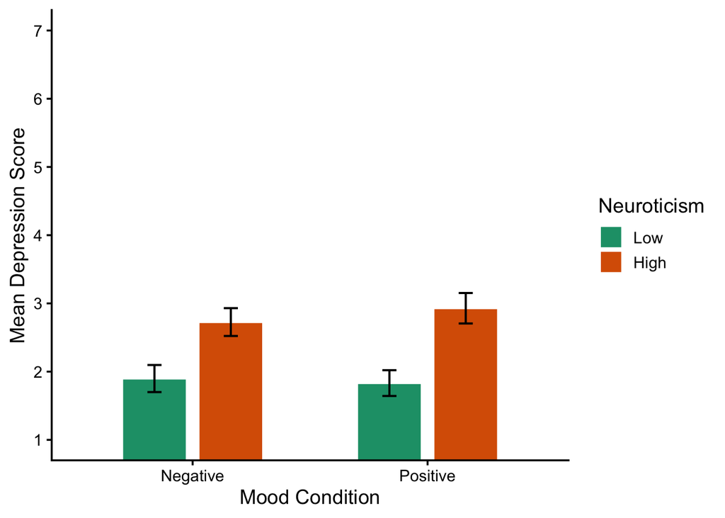

```r
dep_cell_means <- as.data.frame(
  emmeans(a1_dep, ~ moodcond * neo_msplit)
)

p_dep_bar <- ggplot(
  dep_cell_means,
  aes(
    x = moodcond,
    y = emmean,
    fill = neo_msplit
  )
) +
  geom_col(
    position = position_dodge(width = 0.65),
    width = 0.55,
    color = "white"
  ) +
  geom_errorbar(
    aes(
      ymin = lower.CL,
      ymax = upper.CL
    ),
    position = position_dodge(width = 0.65),
    width = 0.12,
    linewidth = 0.7
  ) +
  labs(
    x = "Mood Condition",
    y = "Mean Depression Score",
    fill = "Neuroticism"
  ) +
  scale_fill_brewer(palette = "Dark2") +
  scale_y_continuous(breaks = 1:7) +
  coord_cartesian(ylim = c(1, 7)) +
  theme_classic(base_size = 14)

p_dep_bar
```

The figure shows estimated depression scores by mood condition and neuroticism group. Error bars represent 95% confidence intervals.

### Anxiety Interaction Plot

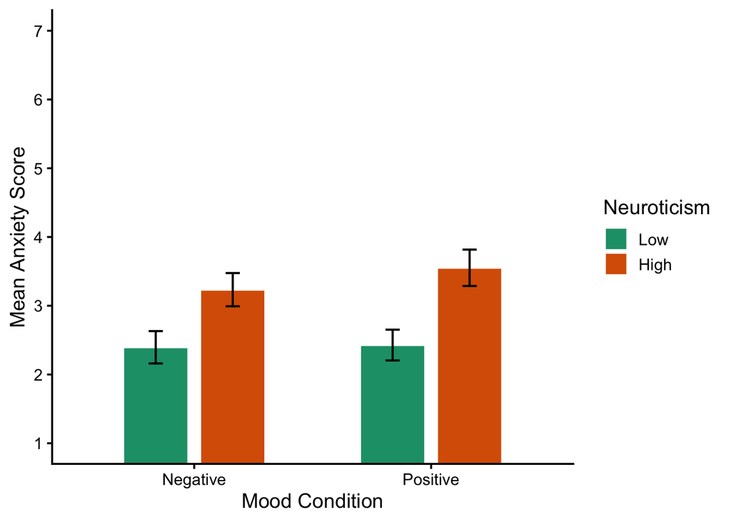

```r
anx_cell_means <- as.data.frame(
  emmeans(a1_anx, ~ moodcond * neo_msplit)
)

p_anx_bar <- ggplot(
  anx_cell_means,
  aes(
    x = moodcond,
    y = emmean,
    fill = neo_msplit
  )
) +
  geom_col(
    position = position_dodge(width = 0.65),
    width = 0.55,
    color = "white"
  ) +
  geom_errorbar(
    aes(
      ymin = lower.CL,
      ymax = upper.CL
    ),
    position = position_dodge(width = 0.65),
    width = 0.12,
    linewidth = 0.7
  ) +
  labs(
    x = "Mood Condition",
    y = "Mean Anxiety Score",
    fill = "Neuroticism"
  ) +
  scale_fill_brewer(palette = "Dark2") +
  scale_y_continuous(breaks = 1:7) +
  coord_cartesian(ylim = c(1, 7)) +
  theme_classic(base_size = 14)

p_anx_bar
```

The figure shows estimated anxiety scores by mood condition and neuroticism group. Error bars represent 95% confidence intervals.

### Export Figures

```r
if (!dir.exists("figures")) {
  dir.create("figures")
}

ggsave(
  filename = "figures/depression_interaction_plot.svg",
  plot = p_dep_bar,
  width = 7,
  height = 5
)

ggsave(
  filename = "figures/anxiety_interaction_plot.svg",
  plot = p_anx_bar,
  width = 7,
  height = 5
)
```

The figures were exported to the `figures/` folder so they can be used in manuscript, poster, or repository materials.

## Results Summary

The primary analyses tested whether mood condition, neuroticism group, and their interaction predicted depression and anxiety scores. Across both ANOVA models, neuroticism group was the only statistically significant predictor. Participants in the high neuroticism group reported higher depression and anxiety scores than participants in the low neuroticism group.

Mood condition was not a statistically significant predictor of either depression or anxiety. The interaction between mood condition and neuroticism group was also not statistically significant for either outcome, indicating that the difference between negative and positive mood conditions did not meaningfully vary across neuroticism groups. The estimated means and interaction plots above provide the full model output and visualize the pattern of results for each outcome.